# slide_deck_GoBike slides

## Ford GoBike System Data By

### Atheir Aljahdali

## proplm

s a Data Scientist, analyze Ford GoBike dataset (https://www.fordgobike.com/) and identify ways by which the ridership can be increased - possibly by offering some deals or incentives. Current options include: Single one-way trip Day pass that allows unlimited 30-minute rides for 24 hours Annual Membership

## dataset

I will be using the Bay Area Bike Share Trips Data (https://cloud.google.com/bigquery/public-data/bay-bike-share) the data in 2018

### Chart 1 boxplot of the **age distubuation**

Question 1 : What is the distribution of ages

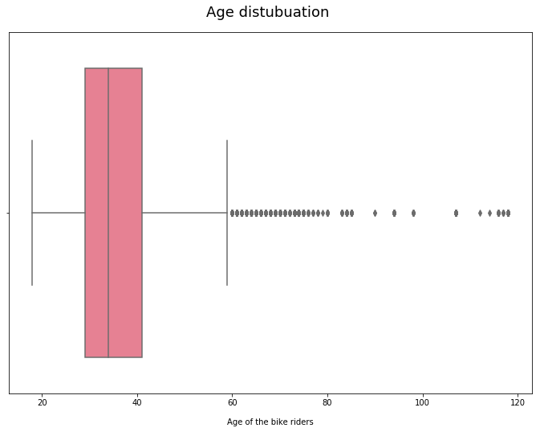

```python
plt.figure(figsize=(11.69, 8.27))
sns.boxplot(x='member_age', data=df_copy, palette='husl', orient='h')
plt.title("Age distubuation ", fontsize=18, y=1.03)
plt.xlabel("Age of the bike riders", fontsize=10, labelpad=14)
plt.savefig('image01.png');
```

Conclusion 1: The age distribution shows there is an outline in the data, I will remove all that data less than record if the ages <=75

### Chart 2 The counts of rieds besied of bikers ages

Question 2: what of ditrubation of bikers ages

```python
def transform_axis_fmt(tick_val, pos):
    if tick_val >= 1000:
        val = int(tick_val/1000)
        return '{:d}K'.format(val)
    elif tick_val >= 1000000:
        val = int(tick_val/1000000)
        return '{:d}M'.format(val)
    else:
        return int(tick_val)
```

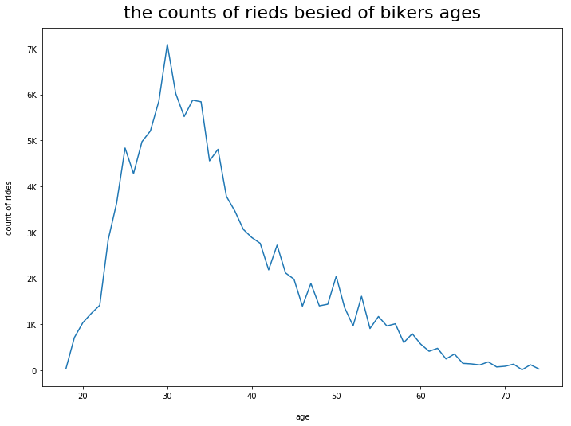

```python
df_copy.groupby('member_age').agg({'bike_id':'count'}).plot(style='-', legend=False, figsize=(11.69, 8.27))
plt.title('the counts of rieds besied of bikers ages', fontsize=22, y=1.015)
plt.xlabel('age', labelpad=16)
plt.ylabel('count of rides', labelpad=16)
ax = plt.gca()
ax.yaxis.set_major_formatter(tick.FuncFormatter(transform_axis_fmt))
plt.savefig('image02.png');
```

Conclusion 2 as shows in chart the ages between 25-40 the bike more that other ages

# Bivariate Exploration

### chart 4 bike ride duration for each month

Question 4. Does sescons reflect on the trip duration ?

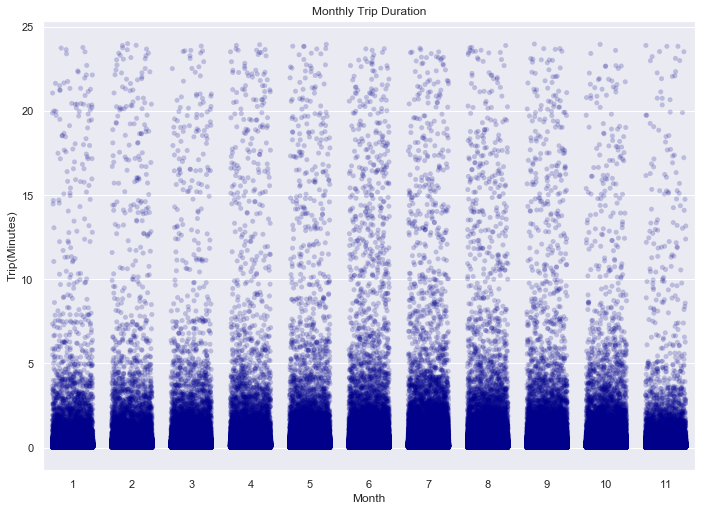

```python
plt.figure(figsize = [11.69, 8.27])
sns.stripplot(data = df_copy , x = 'start_month' , y = 'duration_hour', alpha = 0.2 ,jitter=0.34, color='darkblue' )
plt.title('Monthly Trip Duration')
plt.xlabel('Month')
plt.ylabel('Trip(Minutes)');
plt.savefig('image4.png');
```

Conclusion 4 :as we see between jun-aug has affect the trip duration, but the affect is very limited.

# Multivariate Exploration

### chart 5 The monthly trend of bike rides for both male and female

Question 5: What is monthly count of bikers woman and man ?

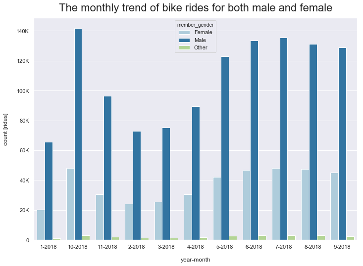

```python
plt.figure(figsize=(11.69, 8.27))
sns.countplot(x='start_year_month', hue='member_gender', palette='Paired', data=df_copy.sort_values(by='start_year_month'))
plt.title('The monthly trend of bike rides for both male and female', fontsize=22, y=1.015)
plt.xlabel('year-month', labelpad=16)
plt.ylabel('count [rides]', labelpad=16)
ax = plt.gca()
ax.yaxis.set_major_formatter(tick.FuncFormatter(transform_axis_fmt))
plt.savefig('image5.png');
```

Conclusion 5: man shows in chart they much more the women how rieds bike

### chart 6 Age trend for male and female

Question 6 :what gender woman or man thy spend more time biking

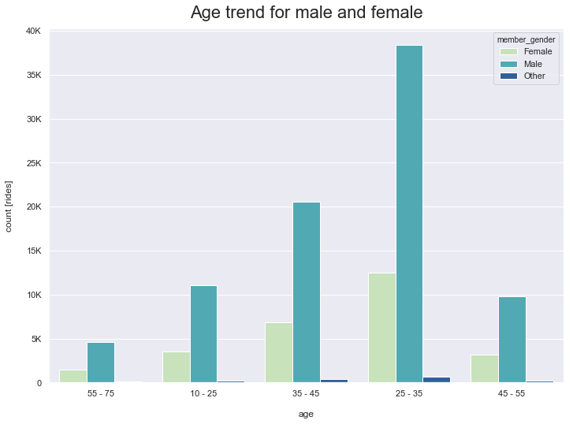

```python
plt.figure(figsize=(11.69, 8.27))
sns.countplot(x='member_age_bins', hue='member_gender', palette='YlGnBu', data=df_copy.sort_values(by='start_year_month'))
plt.title('Age trend for male and female', fontsize=22, y=1.015)
plt.xlabel('age', labelpad=16)
plt.ylabel('count [rides]', labelpad=16)
ax = plt.gca()
ax.yaxis.set_major_formatter(tick.FuncFormatter(transform_axis_fmt))
plt.savefig('image6.png');
```

Conclusion 6 :chart shows the man btween 25-35 bike more other ages and woman between 25-35 bikie more than other ages

# Conclusion

Conclusion 1: The age distribution shows there is an outline in the data, I will remove all that data less than record if the ages <=75

Conclusion 2 as shows in chart the ages between 25-40 the bike more that other ages

Conclusion 4 :as we see between jun-aug has affect the trip duration, but the affect is very limited.

Conclusion 5: man shows in chart they much more the women how rieds bike

Conclusion 6 :chart shows the man btween 25-35 bike more other ages and woman between 25-35 bikie more than other ages

```python
!jupyter nbconvert slide_deck_GoBike.ipynb --to slides --post serve --template output_toggle
```

[output not shown]